# Estudio de predictores

Jaime Ñíguez Baeza

jaime.niguez@um.es

A lo largo de este documento se analizarán los resultados obtenidos en [*1.Entrenamiento_Lasso*](https://github.com/JaimeBioR/circRNA_Parkinson/blob/main/1.Entrenamiento_Lasso.html) y [*2.Entrenamiento_RF*](https://github.com/JaimeBioR/circRNA_Parkinson/blob/main/2.Entrenamiento_RF.html), incluyendo una valoración del rendimiento de los distinto modelos predictivos y de los predictores seleccionados por cada uno de ellos. De esta manera se determinarán aquellos que pasarán al análisis de enriquecimiento.

La presentación de los predictores se llevó a cabo mediante diagramas de Venn, los cuales se realizaron a partir de la información contenida en:

- [Kassambara, A. (2020), “Venn Diagram with R or RStudio: A Million Ways”, Datanovia. Recuperado de https://www.datanovia.com/en/](https://www.datanovia.com/en/blog/venn-diagram-with-r-or-rstudio-a-million-ways)
- [Chen, H. (2022), *VennDiagram: Generate High-Resolution Venn and Euler Plots*. R package version 1.7.3, <https://CRAN.R-project.org/package=VennDiagram>.](https://CRAN.R-project.org/package=VennDiagram)

Para este estudio serán necesarias las siguientes librerías:

```r
library(kableExtra)
library(VennDiagram)
library(gplots)
```

# 1 Rendimiento de los modelos.

El objetivo principal de este estudio es realizar una selección de circRNA que estén relacionados con la enfermedad de Parkinson, por este motivo, la evaluación del rendimiento de los modelos se va a basar no tanto en una capacidad predictiva alta, como en que demuestren contener información suficiente acerca del desarrollo de la enfermedad. Por este motivo no se van a valorar *Sensitivity* y *Specificity* del modelo, sino que consideraremos aquellos que obtengan un *Accuracy* superior al *No Information Rate* (NIR), que en la siguiente tabla queda definido como *AccuracyNull*.

```r
MatricesConfDF <- readRDS("../1. ML/MatConfDF")

kbl(cbind(MatricesConfDF, MatricesConfDF)) %>%
  kable_paper() %>%
  scroll_box(width = "100%", height = "200px")
```

|  | Sensitivity | Specificity | Pos.Pred.Value | Neg.Pred.Value | Precision | Recall | F1 | Prevalence | Detection.Rate | Detection.Prevalence | Balanced.Accuracy | Accuracy | Kappa | AccuracyLower | AccuracyUpper | AccuracyNull | AccuracyPValue | McnemarPValue | N.Pred | Sensitivity | Specificity | Pos.Pred.Value | Neg.Pred.Value | Precision | Recall | F1 | Prevalence | Detection.Rate | Detection.Prevalence | … |
| --- | --- | --- | --- | --- | --- | --- | --- | --- | --- | --- | --- | --- | --- | --- | --- | --- | --- | --- | --- | --- | --- | --- | --- | --- | --- | --- | --- | --- | --- | --- |
| Lasso | 0.8130841 | 0.43750 | 0.7073171 | 0.5833333 | 0.7073171 | 0.8130841 | 0.7565217 | 0.6257310 | 0.5087719 | 0.7192982 | 0.6252921 | 0.6725146 | 0.2638376 | 0.5967099 | 0.7422179 | 0.6257310 | 0.1173751 | 0.0450209 | 238 | 0.8130841 | 0.43750 | 0.7073171 | 0.5833333 | 0.7073171 | 0.8130841 | 0.7565217 | 0.6257310 | 0.5087719 | 0.7192982 | … |
| Lasso.OverS | 0.8411215 | 0.37500 | 0.6923077 | 0.5853659 | 0.6923077 | 0.8411215 | 0.7594937 | 0.6257310 | 0.5263158 | 0.7602339 | 0.6080607 | 0.6666667 | 0.2329425 | 0.5906547 | 0.7367853 | 0.6257310 | 0.1520701 | 0.0035686 | 240 | 0.8411215 | 0.37500 | 0.6923077 | 0.5853659 | 0.6923077 | 0.8411215 | 0.7594937 | 0.6257310 | 0.5263158 | 0.7602339 | … |
| Lasso.UnderS | 0.4953271 | 0.71875 | 0.7464789 | 0.4600000 | 0.7464789 | 0.4953271 | 0.5955056 | 0.6257310 | 0.3099415 | 0.4152047 | 0.6070386 | 0.5789474 | 0.1923380 | 0.5011930 | 0.6539163 | 0.6257310 | 0.9096421 | 0.0000371 | 160 | 0.4953271 | 0.71875 | 0.7464789 | 0.4600000 | 0.7464789 | 0.4953271 | 0.5955056 | 0.6257310 | 0.3099415 | 0.4152047 | … |
| RandomForest | 0.9622642 | 0.34375 | 0.7083333 | 0.8461538 | 0.7083333 | 0.9622642 | 0.8160000 | 0.6235294 | 0.6000000 | 0.8470588 | 0.6530071 | 0.7294118 | 0.3468092 | 0.6221405 | 0.8201109 | 0.6235294 | 0.0265541 | 0.0001746 | 2173 | 0.9622642 | 0.34375 | 0.7083333 | 0.8461538 | 0.7083333 | 0.9622642 | 0.8160000 | 0.6235294 | 0.6000000 | 0.8470588 | … |

El modelo Random Forest presenta un rendimiento destacado sobre los demás, además de ser el único con una diferencia significativa entre *Accuracy* y *NIR* como refleja su $p-value$.

Con un rendimiento más incierto quedarían los modelos de Lasso sin balanceo de clases y Lasso con sobremuestro de la clase minoritaria, los cuales presentan un rendimiento y número de predictores muy similar.

Por último quedaría el modelo Lasso con submuestreo de la clase mayoritaria, con un rendimiento por debajo del *NIR*

Basándonos en estos resultados, los predictores escogidos para el proceso de enriquecimiento serán aquellos importantes en Random Forest. No obstante, a continuación se llevará a cabo un análisis descriptivo de los predictores de todos los modelos para decidir si se considera algún otro conjunto de genes de forma adicional.

# 2 Selección de conjuntos de predictores

Como primer paso cargamos los predictores correspondientes a los distintos modelos, los cuales generamos en los documentos anteriores.

Para los modelos de Lasso se utilizarán los predictores que forman parte del modelo, mientras que en Random Forest aquellos pertenecientes al cuantil 0.9 en cuanto a nivel de importancia.

```r
predictoresLasso_Sort <- readRDS("../1. ML/predictoresLasso_Sort")

predictoresLasso.over <- readRDS("../1. ML/predictoresLasso.over")

predictoresLasso.under <- readRDS("../1. ML/predictoresLasso.under")

predictoresRF_Imp <- readRDS("../1. ML/predictoresRF_Imp")
```

**Concomitancia en los predictores entre modelos**

Se va a visualizar la coincidencia de predictores entre los modelos para decidir si sería interesante incluir algún conjunto además del seleccionado en Random Forest. Una manera sencilla de realizar esta comparación es mediante la representación en un diagrama de Venn, en la que se muestran elementos comunes y únicos para 2 o más subconjuntos.

A continuación se representa el diagrama de Venn para los 4 subconjuntos de predictores (Lasso, Lasso Oversampling, Lasso Undersampling y Random Forest).

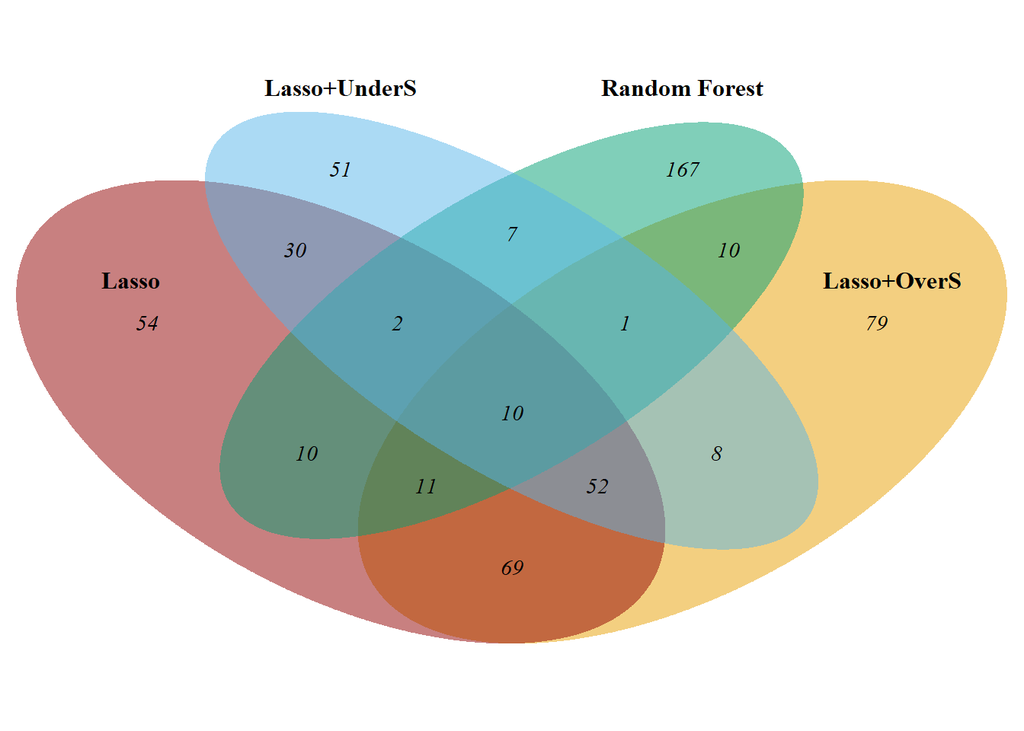

```r
Lasso <- predictoresLasso_Sort$Predictores
LassoOverSampling <- predictoresLasso.over$Predictores
LassoUnderSampling <- predictoresLasso.under$Predictores
RandomForest <- predictoresRF_Imp$Predictores
x <- list(Lasso = predictoresLasso_Sort$Predictores, LassoOverSampling = predictoresLasso.over$Predictores, LassoUnderSampling = predictoresLasso.under$Predictores, RandomForest = predictoresRF_Imp$Predictores)
display_venn <- function(x, ...){
  library(VennDiagram)
  grid.newpage()
  venn_object <- venn.diagram(x, filename = NULL, ...)
  grid.draw(venn_object)
}
display_venn(
        x,
        category.names = c("Lasso" , "Lasso+OverS" , "Lasso+UnderS", "Random Forest"),
        # Circles
        lwd = 2,
        lty = 'blank',
        fill = c("#900000", "#E69F00", "#56B4E9", "#009E73"),
        cex = .9,
        fontface = "italic",
        cat.cex = 1,
        cat.fontface = "bold",
        cat.default.pos = "outer",
        cat.dist = c(0.055, 0.055, 0.1, 0.1)
)
```

```r
ItemsList_x <- venn(x, show.plot = FALSE)
N_Intersecciones <- lengths(attributes(ItemsList_x)$intersections)
InterseccionesGenes <- attributes(ItemsList_x)$intersections
```

Puede observarse cómo existen predictores compartidos en todas las combinaciones, y que los modelos basados en el algoritmo Lasso comparten un número mayor de predictores entre ellos que con el modelo Random Forest. Esto es esperable al comparar algoritmos lineales como Lasso con no lineales como Random Forest, ya que la información extraída de los datos es diferente y se van a considerar combinaciones diferentes de predictores.

Destaca la existencia de 10 predictores centrales a todos los modelos, los cuales son:

```r
cat(InterseccionesGenes$`Lasso:LassoOverSampling:LassoUnderSampling:RandomForest`)
```

```
## circERBB2 circRUFY2 circHERC2P9 circEXTL3 circTPX2 circTLK2 circKDM1A circLIX1.AS1 circPADI4 circCEP350
```

No obstante, en el caso anterior se está incluyendo en la comparación el modelo Lasso con undersampling, el cual presentaba un rendimiento muy bajo, por lo que para una mayor claridad se va a exponer a continuación el diagrama de Venn correspondiente solamente a aquellos modelos que superan el umbral de rendimiento que se estableció con anterioridad (*Acc > NIR*) (Lasso, Lasso Oversampling y Random Forest).

```r
y <- list(Lasso = predictoresLasso_Sort$Predictores, LassoOverSampling = predictoresLasso.over$Predictores, RandomForest = predictoresRF_Imp$Predictores)


display_venn(
        y,
        category.names = c("Lasso", "Lasso OverS.", "Random Forest"),
        # Circles
        lwd = 2,
        lty = 'blank',
        fill = c("#900000","#E69F00","#009E73"),
        # Numbers
        cex = 0.9,
        fontface = "italic",
        # Set names
        cat.cex = 1,
        cat.fontface = "bold",
        cat.default.pos = "outer",
        cat.dist = c(0.1, 0.1, 0.1)
)
```

[figure not shown]

```r
ItemsList_y <- venn(y, show.plot = FALSE)
N_Intersecc_LLR <- lengths(attributes(ItemsList_y)$intersections)
InterseccGenes_LLR <- attributes(ItemsList_y)$intersections
```

En este caso puede observarse cómo el número central de predictores asciende hasta 21. Estos predictores serán considerados especialmente en el apartado final de nuestro estudio, ya que pueden suponer elementos clave en la elaboración de la variable respuesta, siendo de esta manera biomarcadores candidatos más fiables.

Por otro lado, se puede observar cómo los dos modelos basados en Lasso no son muy similares únicamente en cuanto a los predictores totales que conservan, los cuales vimos que eran 238 (Lasso) y 240 (Lasso Oversampling), sino que además la concomitancia de predictores entre ellos y con el modelo Random Forest sigue un mismo patrón.

Hay que destacar que aunque comparten un número alto de predictores (142), el hecho de que presenten 84 y 87 elementos únicos puede representar información relevante a la hora de realizar el análisis de enriquecimiento. Por este motivo se van a mantener los predictores procedentes de ambos modelos y se van a utilizar junto con el top procedente de Random Forest en el siguiente documento durante el análisis de enriquecimiento.

Por último, quedaría exponer el grupo de 21 predictores centrales a estos 3 modelos, el cual está compuesto por:

```r
cat(InterseccGenes_LLR$`Lasso:LassoOverSampling:RandomForest`)
```

```
## circERBB2 circRUFY2 circHERC2P9 circEXTL3 circDDX50 circRNASEH2B circIL21R circTPX2 circDEPDC1 circTLK2 circSEC24A circB4GALT5 circKDM1A circLIX1.AS1 circPOC5 circSTK39 circPADI4 circUBE2I circCEP350 circRABGAP1L circTFEC
```

# 3 Conclusiones

La existencia de un rendimiento similar en varios modelos y el hecho de que estén compuestos por un número relativamente alto de predictores diferentes genera una situación en la que descartar alguno de ellos podría ocasionar una pérdida de información. Para evitar esto, se considerarán todos los conjuntos de circRNA de modelos exitosos y se realizará un filtrado de los resultados obtenidos en el siguiente apartado, contenido en el documento [4.Analisis_Enriquecimiento](https://github.com/JaimeBioR/circRNA_Parkinson/blob/main/4%2CAnalisis_Enriquecimiento.html).

# 4 Session Info